# Tugas 2

Aisyah Nuruzzahra Tirtasuwanda

2023-09-12

```r
library(forecast)
```

```r
library(graphics)
library(TTR)
library(TSA)
library(rio)
library(ggplot2)
library(lmtest)
library(orcutt)
library(HoRM)
library(corrplot)
library(RColorBrewer)
library(scales)
```

```r
data_co2 <- import("https://github.com/zahratirtasuwanda/prak-mpdw/raw/main/Pertemuan%202/Co2%20Fuel%20-%20Canada.csv")
```

```r
## Eksplorasi Analisis Data

#Ekplorasi data
summary(data_co2)
```

```
##       Year        Country           Gas Flaring     Per Capita
##  Min.   :1950   Length:65          Min.   :   0   Min.   :2.880
##  1st Qu.:1966   Class :character   1st Qu.: 855   1st Qu.:3.520
##  Median :1982   Mode  :character   Median :1114   Median :4.340
##  Mean   :1982                      Mean   :1002   Mean   :4.095
##  3rd Qu.:1998                      3rd Qu.:1234   3rd Qu.:4.620
##  Max.   :2014                      Max.   :1674   Max.   :4.970
##  Bunker fuels (Not in Total)
##  Min.   : 758
##  1st Qu.:1264
##  Median :1535
##  Mean   :1718
##  3rd Qu.:2044
##  Max.   :3162
```

```r
#Membuat matriks korelasi
korelasi <- cor(data_co2[,3:5])
korelasi
```

```
##                             Gas Flaring  Per Capita Bunker fuels (Not in Total)
## Gas Flaring                   1.0000000  0.37309072                  0.12941477
## Per Capita                    0.3730907  1.00000000                 -0.02878065
## Bunker fuels (Not in Total)   0.1294148 -0.02878065                  1.00000000
```

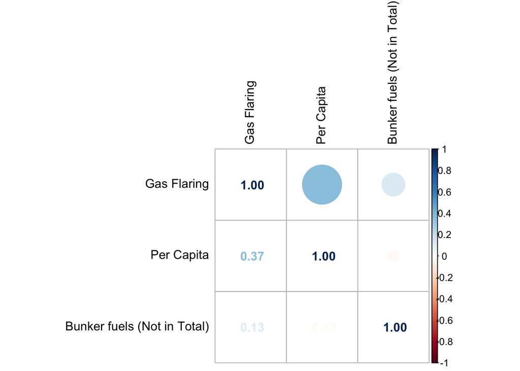

```r
corrplot.mixed(korelasi, upper = 'circle', lower = 'number', order = "original",
               tl.col="black", tl.pos = "lt",diag = 'l',
               number.digits=2, number.cex=1)
```

## Eksplorasi Data

Sebelum melakukan regresi, akan diperlihatkan plot time-series dari Fossil Fuel Canada Periode 1950-2014

```r
#Membentuk objek time series
data.ts<-ts(data_co2$`Bunker fuels (Not in Total)`)
data.ts
```

```
## Time Series:
## Start = 1
## End = 65
## Frequency = 1
##  [1] 1230 1335 1369 1489 1335 1480 1535 1802 1541 1828 1851 1937 2044 2148 2220
## [16] 2455 2686 2731 2975 3119 2780 2644 2858 3162 2914 2416 2350 2308 2580 1992
## [31] 1896 1336 1077  955  913  758  774  994 1112 1309 1526 1487 1564 1415 1505
## [46] 1577 1642 1609 1807 1748 1760 1869 1507 1014 1264 1459 1292 1173 1168 1195
## [61] 1518 1223 1171 1048  914
```

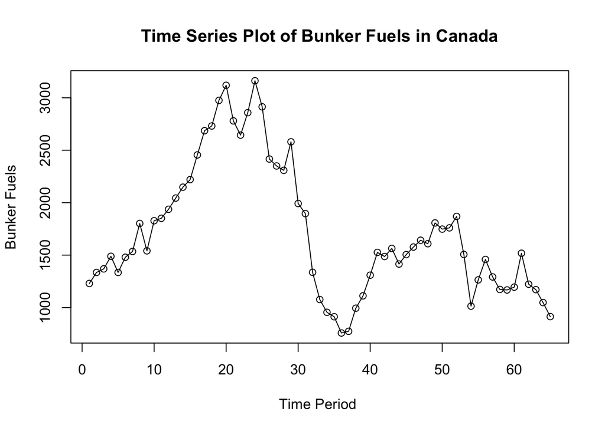

```r
#Membuat plot time series
ts.plot(data.ts, xlab="Time Period ", ylab="Bunker Fuels", main= "Time Series Plot of Bunker Fuels in Canada")
points(data.ts)
```

```r
## Regresi

#Pembuatan Model Regresi
#model regresi
y <- data_co2$`Bunker fuels (Not in Total)`
x1 <- data_co2$`Gas Flaring`
x2 <- data_co2$`Per Capita`

model<- lm(y~x1+x2, data_co2)
summary(model)
```

```
##
## Call:
## lm(formula = y ~ x1 + x2, data = data_co2)
##
## Residuals:
##     Min      1Q  Median      3Q     Max
## -1037.3  -410.7  -170.2   291.2  1442.4
##
## Coefficients:
##              Estimate Std. Error t value Pr(>|t|)
## (Intercept) 1770.1573   492.9384   3.591 0.000651 ***
## x1             0.2930     0.2434   1.204 0.233256
## x2           -84.3644   127.4579  -0.662 0.510488
## ---
## Signif. codes:  0 '***' 0.001 '**' 0.01 '*' 0.05 '.' 0.1 ' ' 1
##
## Residual standard error: 626.4 on 62 degrees of freedom
## Multiple R-squared:  0.02365,    Adjusted R-squared:  -0.007848
## F-statistic: 0.7508 on 2 and 62 DF,  p-value: 0.4762
```

$$y_i = 1770.1573+0.2930X1-84.3644X2$$

Berdasarkan ringkasan model dapat diketahui bahwa hasil uji F memiliki p-value > $\alpha$ (5%). Artinya, semua variabel tidak berpengaruh nyata terhadap model.

Selanjutnya dapat dilihat juga nilai $R^2=0.02365$. Artinya, sebesar 2.365% keragaman Bunker Fuels dapat dijelaskan oleh peubah Gas Flaring, dan Per Capita Hasil ini menunjukkan hasil yang kurang bagus sehingga kita perlu melakukan uji terhadap sisaannya seperti berikut ini.

```r
#sisaan dan fitted value
sisaan<- residuals(model)
fitValue<- predict(model)
```

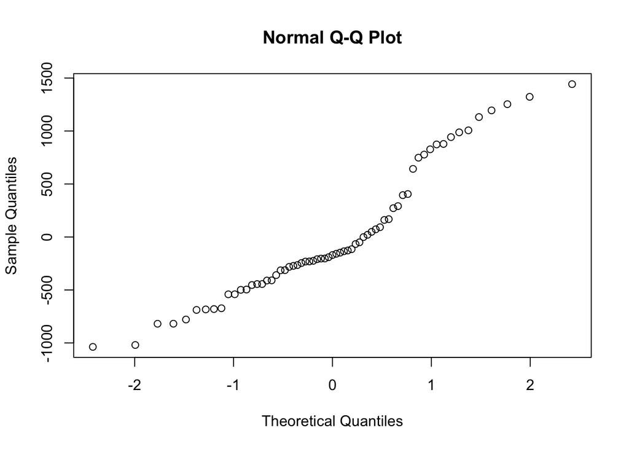

```r
#Diagnostik dengan eksploratif
par(mfrow = c(1,1))
qqnorm(sisaan)
```

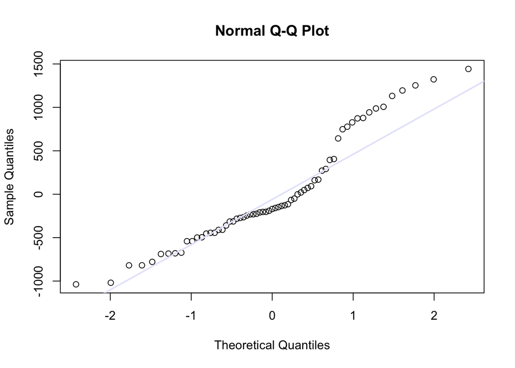

```r
#Normal Q-Q Plot
qqnorm(sisaan)
qqline(sisaan, col = "lavender", lwd = 2)
```